# Дисперсионный анализ, часть 2

## Объёмы выборок в группах

```r
table(pengs$sp, pengs$sex)
```

```
            female male
  Adelie        73   73
  Chinstrap     34   34
  Gentoo        58   61
```

- Группы разного размера

## Посмотрим на график

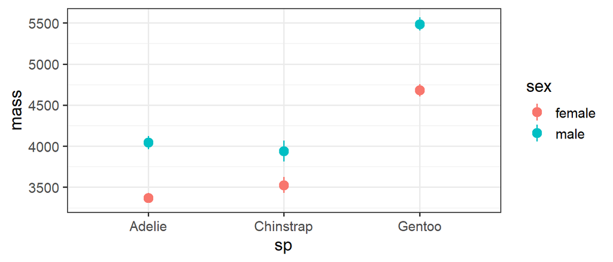

```r
library(ggplot2)
theme_set(theme_bw(base_size = 14))
gg_mass <- ggplot(data = pengs, aes(x = sp, y = mass, colour = sex)) +
  stat_summary(geom = 'pointrange', fun.data = mean_cl_normal)
gg_mass
```

# Многофакторный дисперсионный анализ

## Многофакторный дисперсионный анализ

Дисперсионный анализ становится многофакторным, если в модели используется несколько дискретных факторов.

Дизайн такого рода анализа может быть разным.

### Вложенные (иерархичные) модели

В модели внутри какого-то фактора расположены дополнительные предикторы. Особенность таких моделей в том, что категории вложенных факторов в пределах уровней основного фактора различны.

**Пример:** измерения обилия беспозвоночных животных на литорали в разные годы и месяцы.

### Факторные модели

Дизайн эксперимента предполагает, что разные факторы пересекаются друг с другом. Таким образом возможны любые комбинации между разными уровнями разных факторов.

Наш случай! Факторов может быть несколько, мы будем разбираться на примере двухфакторного дисперсионного анализа.

## Какие бывают факторы

| Свойства | Фиксированные факторы | Случайные факторы |
| --- | --- | --- |
| Уровни фактора | фиксированные, заранее определённые и потенциально воспроизводимые уровни | случайная выборка из всех возможных уровней |
| Используются для тестирования гипотез | о средних значениях отклика между уровнями фактора $H_0: \mu_1 = \mu_2 = \ldots = \mu_i = \mu$ | о дисперсии отклика между уровнями фактора $H_0: \sigma_{rand.fact.}^2 = 0$ |
| Выводы можно экстраполировать | только на уровни из анализа | на все возможные уровни |

Мы сейчас работаем с фиксированными факторами. В случае, когда в модели присутствуют и фиксированные, и случайные факторы — используют смешанные линейные модели, о которых мы поговорим позже.

## Взаимодействие факторов

При добавлении новых факторов в модель появляется **взаимодействие** факторов.

Взаимодействие факторов возникает, когда у одного фактора эффект разный в зависимости от уровней другого.

Такое взаимодействие необходимо учитывать, в т.ч. при интерпретации результатов.

## Что такое взаимодействие дискретных предикторов

Взаимодействие факторов — когда эффект фактора B разный в зависимости от уровней фактора A и наоборот.

## Влияют ли главные эффекты и взаимодействие?

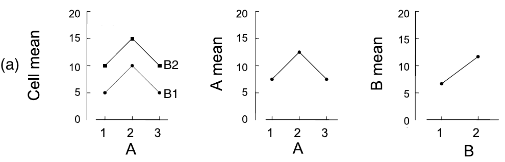

Quinn, Keough, 2002, fig.9.3

- взаимодействие не значимо, и не мешает интерпретировать эффекты факторов.
  - фактор А влияет
  - фактор В влияет

## Влияют ли главные эффекты и взаимодействие?

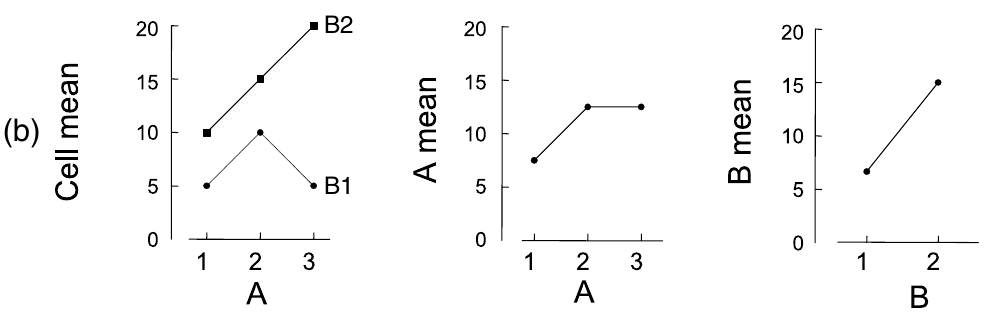

Quinn, Keough, 2002, fig.9.3

- взаимодействие значимо и мешает интерпретировать влияние факторов отдельно:
  - для В2 зависимая переменная возрастает с изменением уровня А
  - для В1 зависимая переменная возрастает только на А2, но не различается на А1 и А3
- **если смотреть на главные эффекты, можно сделать неправильные выводы (о факторе А):**
  - фактор А влияет, группы А2 и А3 не отличаются
  - фактор В влияет, в группе В2 зависимая переменная больше, чем в В1

## Влияют ли главные эффекты и взаимодействие?

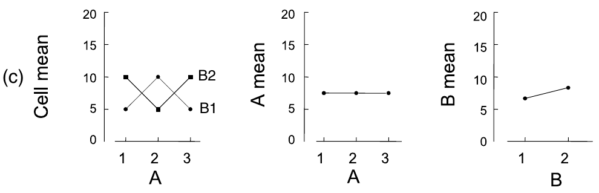

Quinn, Keough, 2002, fig.9.3

- взаимодействие значимо и мешает интерпретировать влияние факторов отдельно:
  - на уровне A2 меняется порядок различий уровней фактора B
- **если смотреть на главные эффекты, можно сделать неправильные выводы:**
  - факторы А и В не влияют

## Взаимодействие факторов может маскировать главные эффекты

Если есть значимое взаимодействие, то - главные эффекты обсуждать не имеет смысла  
- пост хок тесты проводятся только для взаимодействия

# Двухфакторный дисперсионный анализ в параметризации индикаторов

## Переменные-индикаторы

В нашем примере отклик — вес пингвина, и два дискретных фактора:

- `sex` — 2 уровня (базовый `female`), для кодирования нужна одна переменная.

```r
contr.treatment(levels(pengs$sex))
```

```
       male
female    0
male      1
```

- `sp` — 3 уровня (базовый `Adelie`), для кодирования нужно две переменных.

```r
contr.treatment(levels(pengs$sp))
```

```
          Chinstrap Gentoo
Adelie            0      0
Chinstrap         1      0
Gentoo            0      1
```

## Переменные-индикаторы

Дополнительные переменные понадобятся, чтобы учесть взаимодействие факторов.

Фрагмент модельной матрицы:

| sex | sp | sexsp $x_1$ | spChinstrap $x_2$ | spGentoo $x_3$ | sexmale:Chinstrap $x_4$ | sexmale:Gentoo $x_5$ |
| --- | --- | --- | --- | --- | --- | --- |
| female | Adelie | 0 | 0 | 0 | 0 | 0 |
| male | Adelie | 1 | 0 | 0 | 0 | 0 |
| female | Chinstrap | 0 | 1 | 0 | 0 | 0 |
| male | Chinstrap | 1 | 1 | 0 | 1 | 0 |
| female | Gentoo | 0 | 0 | 1 | 0 | 0 |
| male | Gentoo | 1 | 0 | 1 | 0 | 1 |

## Уравнение линейной модели в параметризации индикаторов

$$y_{i} = b_0 + b_1 x_{1i} + b_2 x_{2i} + b_3 x_{3i} + b_4 x_{4i} + b_5 x_{5i} + e_{i}$$

- $b_0$ — значение отклика для самок вида Adelie (на базовом уровне обоих факторов).

Отклонения относительно базового уровня обоих факторов:

- $b_1$ — для самцов Adelie;
- $b_2$ и $b_3$ — для самок Chinstrap и Gentoo, соответственно;
- $b_4$ и $b_5$ — для самцов Chinstrap и Gentoo, соответственно.

## Подбираем линейную модель в параметризации индикаторов (contr.treatment)

```r
mod_treat_pengs <- lm(mass ~ sex * sp, data = pengs)
mod_treat_pengs
```

```
Call:
lm(formula = mass ~ sex * sp, data = pengs)

Coefficients:
        (Intercept)              sexmale          spChinstrap
               3369                  675                  158
           spGentoo  sexmale:spChinstrap     sexmale:spGentoo
               1311                 -263                  130
```

Общее уравнение модели

$$\begin{aligned}\widehat{mass}_{i} = 3369 + 675 sex_{male,i} + 158 sp_{Chinstrap\,i} + 1311 sp_{Gentoo\,i} + \\ - 263 sex_{male}\ sp_{Chinstrap\,i} + 130 sex_{male}\ sp_{Gentoo\,i} \end{aligned}$$

# Двухфакторный дисперсионный анализ в параметризации эффектов

## Переменные-эффекты

В нашем примере отклик — вес пингвина, и два дискретных фактора:

- `sex` — 2 уровня (базовый `female`), для кодирования нужна одна переменная.

```r
contr.sum(levels(pengs$sex))
```

```
       [,1]
female    1
male     -1
```

- `sp` — 3 уровня (базовый `Adelie`), для кодирования нужно две переменных.

```r
contr.sum(levels(pengs$sp))
```

```
          [,1] [,2]
Adelie       1    0
Chinstrap    0    1
Gentoo      -1   -1
```

## Переменные-эффекты

Дополнительные переменные понадобятся, чтобы учесть взаимодействие факторов.

Фрагмент модельной матрицы:

[output not shown]

## Уравнение линейной модели в параметризации эффектов

$$y_{i} = b_0 + b_1 x_{1i} + b_2 x_{2i} + b_3 x_{3i} + b_4 x_{4i} + b_5 x_{5i} + e_{i}$$

- $b_0$ — среднее значение отклика по всем данным.

Отклонения от общего среднего значений отклика:

- $b_1$ — в зависимости от пола (фактор `sex`);
- $b_2$ и $b_3$ — в зависимости от вида (фактор `sp`);
- $b_4$ и $b_5$ — для пола в зависимости от вида (взаимодействие).

## Подбираем линейную модель в параметризации эффектов (contr.sum)

```r
mod_sum_pengs <- lm(mass ~ sex * sp, data = pengs,
                    contrasts = list(sp = 'contr.sum', sex = 'contr.sum'))
coef(mod_sum_pengs)
```

```
(Intercept)        sex1         sp1         sp2    sex1:sp1
     4173.8      -315.3      -467.7      -440.8       -22.1
   sex1:sp2
      109.4
```

# Диагностика линейной модели

## Диагностика линейной модели

Нужно проверить, выполняются ли условия применимости для модели в нужной параметризации.

Данные для анализа остатков:

```r
mod_treat_peng_diag <- fortify(mod_treat_pengs)
head(mod_treat_peng_diag, 2)
```

```
  mass    sex     sp   .hat .sigma .cooksd .fitted .resid .stdresid
1 3750   male Adelie 0.0137    309 0.00211    4043   -293    -0.955
2 3800 female Adelie 0.0137    309 0.00456    3369    431     1.403
```

## График расстояния Кука

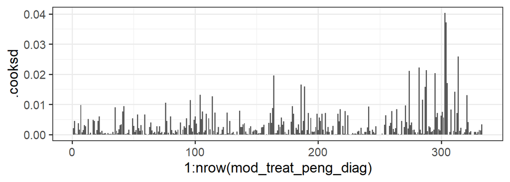

```r
ggplot(mod_treat_peng_diag, aes(x = 1:nrow(mod_treat_peng_diag), y = .cooksd)) +
  geom_bar(stat = 'identity')
```

- Влиятельных наблюдений нет.

## График остатков от предсказанных значений

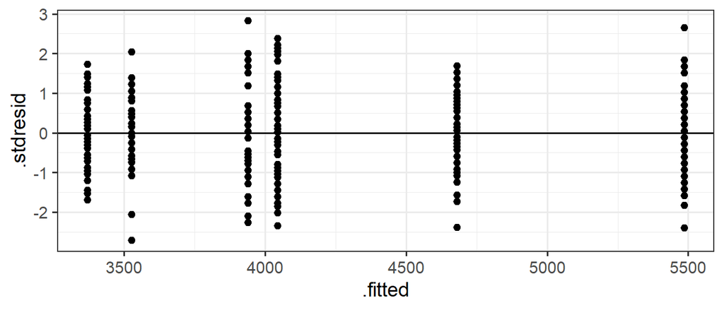

```r
gg_resid <- ggplot(data = mod_treat_peng_diag, aes(x = .fitted, y = .stdresid)) +
  geom_point() + geom_hline(yintercept = 0)
gg_resid
```

- Влиятельных наблюдений нет (все в пределах 3 SD).
- Несколько наблюдений не совсем обычны (2SD < .stdresid < 3SD), но поскольку расстояние Кука для них небольшое, это нестрашно.

## График зависимости остатков от предикторов в модели

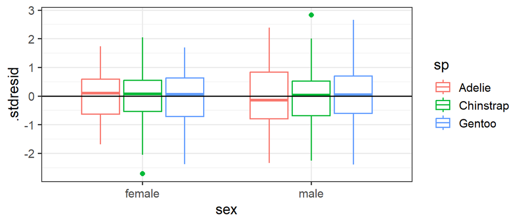

```r
ggplot(data = mod_treat_peng_diag, aes(x = sex, y = .stdresid, colour = sp)) +
  geom_boxplot() + geom_hline(yintercept = 0)
```

Удобнее смотреть на боксплот. Нет гетерогенности дисперсии, всё хорошо!

## Квантильный график остатков

```r
library(car)
qqPlot(mod_treat_pengs, id = FALSE)
```

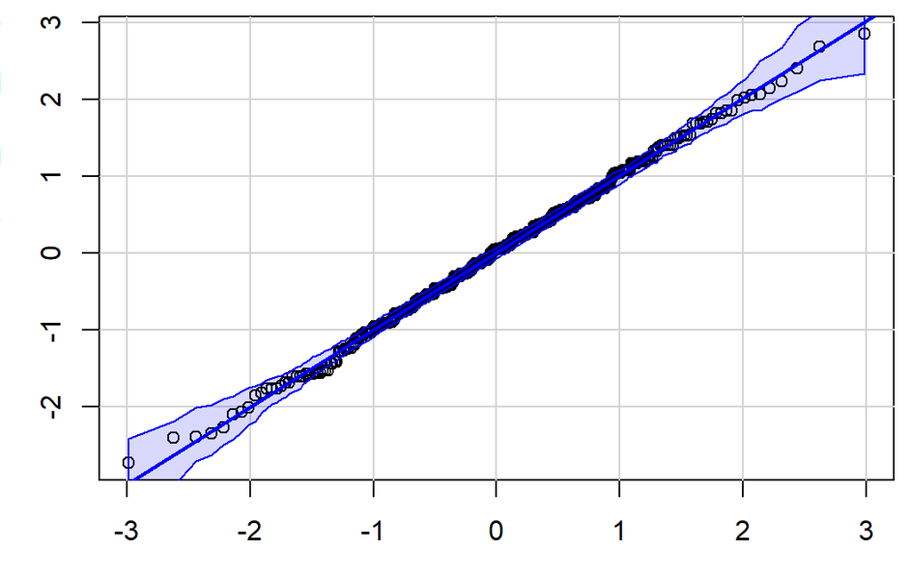

- Отклонений от нормального распределения нет.

# Несбалансированные данные, типы сумм квадратов

## Несбалансированные данные — когда численности в группах по факторам различаются

Например так,

|  | A1 | A2 | A3 |
| --- | --- | --- | --- |
| B1 | 5 | 5 | 5 |
| B2 | 5 | 4 | 5 |

или так,

|  | A1 | A2 | A3 |
| --- | --- | --- | --- |
| B1 | 3 | 8 | 4 |
| B2 | 4 | 7 | 4 |

## Проблемы из-за несбалансированности данных

- Оценки средних в разных группах с разным уровнем точности (Underwood 1997)
- ANOVA менее устойчив к отклонениям от условий применимости (особенно от **гомогенности** дисперсий) при разных размерах групп (Quinn Keough 2002, section 8.3)
- Проблемы с расчётом мощности. Если $\sigma_{\varepsilon}^2 > 0$ и размеры выборок разные, то $MS_x \over MS_e$ не следует F-распределению (Searle et al. 1992).

Старайтесь *планировать* группы равной численности! Но если не получилось — не страшно:

- Для фиксированных эффектов неравные размеры — проблема при нарушении условий применимости только, если значения доверительной вероятности *p* близки к выбранному критическому уровню значимости $\alpha$.

## Суммы квадратов в многофакторном дисперсионном анализе со взаимодействием

### Если данные сбалансированы, то …

- взаимодействие и эффекты факторов независимы (в любой параметризации),
- все суммы квадратов и соответствующие тесты можно посчитать в одном анализе,
- результат не зависит от порядка включения факторов в модель.

### Если данные несбалансированы, то …

- суммы квадратов для факторов не равны общей сумме квадратов,
- для вычислений используется регрессионный подход (несколько сравнений вложенных моделей),
- результат анализа может зависеть от порядка включения факторов в модель.

## Порядок тестирования значимости предикторов в дисперсионном анализе

| “Типы сумм квадратов” | I тип | II тип | III тип |
| --- | --- | --- | --- |
| Название | Последовательный | Без учёта взаимодействий высоких порядков | Иерархический |

## Порядок тестирования значимости предикторов в дисперсионном анализе

| “Типы сумм квадратов” | I тип | II тип | III тип |
| --- | --- | --- | --- |
| Название | Последовательный | Без учёта взаимодействий высоких порядков | Иерархический |
| Порядок расчёта SS | SS(A) SS(B\|A) SS(AB\|B, A) | SS(A\|B) SS(B\|A) SS(AB\|B, A) | SS(A\|B, AB) SS(B\|A, AB) SS(AB\|B, A) |
| Величина эффекта зависит от выборки в группе | Да | Да | Нет |
| Результат зависит от порядка включения факторов в модель | Да | Нет | Нет |
| Параметризация | Любая | Любая | Только параметризация эффектов |
| Команда R | aov(), anova() | Anova() (пакет car) | Anova() (пакет car) |

**Осторожно!** Тестируя предикторы в разном порядке, вы тестируете разные гипотезы!

## Если данные сбалансированы, то …

- При использовании любого типа сумм квадратов результаты расчётов будут одинаковы.

## Если данные несбалансированы, то …

- Результаты зависят от выбранного типа сумм квадратов (т.к. он определяет, какие гипотезы при этом тестируются).

Для несбалансированных данных рекомендуют **суммы квадратов III типа**, если есть взаимодействие факторов (Maxwell & Delaney 1990, Milliken, Johnson 1984, Searle 1993, Yandell 1997, Glantz, Slinker 2000).

# Многофакторный дисперсионный анализ в R

## Дисперсионный анализ со II типом сумм квадратов

При таком способе сначала тестируется взаимодействие, затем отдельные факторы в модели без взаимодействия.

```r
mod_treat_pengs <- lm(mass ~ sp * sex, data = pengs)
library(car)
Anova(mod_treat_pengs, type = "II")
```

```
Anova Table (Type II tests)

Response: mass
             Sum Sq  Df F value Pr(>F)
sp        143401584   2  749.02 <2e-16 ***
sex        37090262   1  387.46 <2e-16 ***
sp:sex      1676557   2    8.76 0.0002 ***
Residuals  31302628 327
---
Signif. codes:  0 '***' 0.001 '**' 0.01 '*' 0.05 '.' 0.1 ' ' 1
```

## Дисперсионный анализ c III типом сумм квадратов

Опишем процедуру на тот случай, если вдруг вам понадобится воспроизвести в R дисперсионный анализ с III типом сумм квадратов.

При этом способе вначале тестируют взаимодействие, когда все другие факторы есть в модели. Затем тестируют факторы, когда все другие факторы и взаимодействие есть в модели.

**Внимание: при использовании III типа сумм квадратов, нужно обязательно указывать тип контрастов для факторов** (`contrasts=list(фактор_1 = contr.sum, фактор_2=contr.sum)`).

```r
mod_sum_pengs <- lm(mass ~ sp * sex, data = pengs,
                    contrasts = list(sp = 'contr.sum', sex = 'contr.sum'))
Anova(mod_sum_pengs, type = "III")
```

```
Anova Table (Type III tests)

Response: mass
                Sum Sq  Df  F value Pr(>F)
(Intercept) 5232595969   1 54661.83 <2e-16 ***
sp           143001222   2   746.92 <2e-16 ***
sex           29851220   1   311.84 <2e-16 ***
sp:sex         1676557   2     8.76 0.0002 ***
Residuals     31302628 327
---
Signif. codes:  0 '***' 0.001 '**' 0.01 '*' 0.05 '.' 0.1 ' ' 1
```

## Почему для расчёта III типа сумм квадратов обязательно использовать параметризацию эффектов?

Для расчёта III типа сумм квадратов нужно иметь возможность удалить из модели влияние предиктора и одновременно оставить в ней взаимодействие (т.е. предикторы и взаимодействие были независимы друг от друга).

**В параметризации индикаторных переменных предикторы и взаимодействие коллинеарны**, т.е. суммы квадратов III типа будут рассчитаны неправильно.

```r
vif(mod_treat_pengs)
```

```
       GVIF Df GVIF^(1/(2*Df))
sp     4.07  2            1.42
sex    2.28  1            1.51
sp:sex 6.69  2            1.61
```

**В параметризации эффектов переменных предикторы и взаимодействие независимы**, значит получатся верные суммы квадратов III типа.

```r
vif(mod_sum_pengs)
```

```
       GVIF Df GVIF^(1/(2*Df))
sp     1.00  2            1.00
sex    1.11  1            1.05
sp:sex 1.11  2            1.03
```